# Overview

Dataset info

| Number of variables | 158 |
| --- | --- |
| Number of observations | 19622 |
| Total Missing (%) | 45.2% |
| Total size in memory | 23.7 MiB |
| Average record size in memory | 1.2 KiB |

Variables types

| Numeric | 92 |
| --- | --- |
| Categorical | 35 |
| Boolean | 0 |
| Date | 1 |
| Text (Unique) | 0 |
| Rejected | 30 |
| Unsupported | 0 |

Warnings

- `accel_belt_y` is highly correlated with `avg_roll_belt` (ρ = 0.91761) Rejected
- `accel_dumbbell_x` has 312 / 1.6% zeros Zeros
- `amplitude_pitch_arm` is highly correlated with `stddev_yaw_arm` (ρ = 0.95753) Rejected
- `amplitude_pitch_belt` has 19216 / 97.9% missing values Missing
- `amplitude_pitch_dumbbell` has 19216 / 97.9% missing values Missing
- `amplitude_pitch_forearm` has 19216 / 97.9% missing values Missing
- `amplitude_roll_arm` is highly correlated with `stddev_pitch_arm` (ρ = 0.98142) Rejected
- `amplitude_roll_belt` has 19216 / 97.9% missing values Missing
- `amplitude_roll_dumbbell` has 19216 / 97.9% missing values Missing
- `amplitude_roll_forearm` has 19216 / 97.9% missing values Missing
- `amplitude_yaw_arm` has 19216 / 97.9% missing values Missing
- `amplitude_yaw_belt` has 19216 / 97.9% missing values Missing
- `amplitude_yaw_dumbbell` has 19216 / 97.9% missing values Missing
- `amplitude_yaw_forearm` has 19216 / 97.9% missing values Missing
- `avg_pitch_arm` has 19216 / 97.9% missing values Missing
- `avg_pitch_belt` is highly correlated with `pitch_belt` (ρ = 0.9985) Rejected
- `avg_pitch_dumbbell` has 19216 / 97.9% missing values Missing
- `avg_pitch_forearm` has 19216 / 97.9% missing values Missing
- `avg_roll_arm` is highly correlated with `roll_arm` (ρ = 0.91276) Rejected
- `avg_roll_belt` is highly correlated with `min_pitch_belt` (ρ = 0.98396) Rejected
- `avg_roll_dumbbell` has 19216 / 97.9% missing values Missing
- `avg_roll_forearm` has 19216 / 97.9% missing values Missing
- `avg_yaw_arm` has 19216 / 97.9% missing values Missing
- `avg_yaw_belt` is highly correlated with `min_roll_belt` (ρ = 0.99367) Rejected
- `avg_yaw_dumbbell` is highly correlated with `max_picth_dumbbell` (ρ = 0.93838) Rejected
- `avg_yaw_forearm` has 19216 / 97.9% missing values Missing
- `gyros_arm_x` has 516 / 2.6% zeros Zeros
- `gyros_arm_y` has 515 / 2.6% zeros Zeros
- `gyros_arm_z` has 524 / 2.7% zeros Zeros
- `gyros_belt_x` has 1039 / 5.3% zeros Zeros
- `gyros_belt_y` has 4719 / 24.0% zeros Zeros
- `gyros_belt_z` has 1767 / 9.0% zeros Zeros
- `gyros_dumbbell_x` has 614 / 3.1% zeros Zeros
- `gyros_dumbbell_x` is highly skewed (γ1 = -126.34) Skewed
- `gyros_dumbbell_y` has 535 / 2.7% zeros Zeros
- `gyros_dumbbell_y` is highly skewed (γ1 = 31.653) Skewed
- `gyros_dumbbell_z` has 599 / 3.1% zeros Zeros
- `gyros_dumbbell_z` is highly skewed (γ1 = 135.97) Skewed
- `gyros_forearm_x` has 523 / 2.7% zeros Zeros
- `gyros_forearm_y` has 383 / 2.0% zeros Zeros
- `gyros_forearm_y` is highly skewed (γ1 = 51.332) Skewed
- `gyros_forearm_z` is highly correlated with `gyros_dumbbell_z` (ρ = 0.93304) Rejected
- `kurtosis_picth_arm` has 19216 / 97.9% missing values Missing
- `kurtosis_picth_arm` has a high cardinality: 328 distinct values Warning
- `kurtosis_picth_belt` has 19216 / 97.9% missing values Missing
- `kurtosis_picth_belt` has a high cardinality: 317 distinct values Warning
- `kurtosis_picth_dumbbell` has 19216 / 97.9% missing values Missing
- `kurtosis_picth_dumbbell` has a high cardinality: 401 distinct values Warning
- `kurtosis_picth_forearm` has 19216 / 97.9% missing values Missing
- `kurtosis_picth_forearm` has a high cardinality: 323 distinct values Warning
- `kurtosis_roll_arm` has 19216 / 97.9% missing values Missing
- `kurtosis_roll_arm` has a high cardinality: 330 distinct values Warning
- `kurtosis_roll_belt` has 19216 / 97.9% missing values Missing
- `kurtosis_roll_belt` has a high cardinality: 397 distinct values Warning
- `kurtosis_roll_dumbbell` has 19216 / 97.9% missing values Missing
- `kurtosis_roll_dumbbell` has a high cardinality: 398 distinct values Warning
- `kurtosis_roll_forearm` has 19216 / 97.9% missing values Missing
- `kurtosis_roll_forearm` has a high cardinality: 322 distinct values Warning
- `kurtosis_yaw_arm` has 19216 / 97.9% missing values Missing
- `kurtosis_yaw_arm` has a high cardinality: 395 distinct values Warning
- `kurtosis_yaw_belt` has 19216 / 97.9% missing values Missing
- `kurtosis_yaw_dumbbell` has 19216 / 97.9% missing values Missing
- `kurtosis_yaw_forearm` has 19216 / 97.9% missing values Missing
- `magnet_belt_x` has 350 / 1.8% zeros Zeros
- `max_picth_arm` has 19216 / 97.9% missing values Missing
- `max_picth_belt` is highly correlated with `total_accel_belt` (ρ = 0.97504) Rejected
- `max_picth_dumbbell` has 19216 / 97.9% missing values Missing
- `max_picth_forearm` has 19216 / 97.9% missing values Missing
- `max_roll_arm` has 19216 / 97.9% missing values Missing
- `max_roll_belt` is highly correlated with `yaw_belt` (ρ = 0.98245) Rejected
- `max_roll_dumbbell` has 19216 / 97.9% missing values Missing
- `max_roll_forearm` has 19216 / 97.9% missing values Missing
- `max_yaw_arm` has 19216 / 97.9% missing values Missing
- `max_yaw_belt` has 19216 / 97.9% missing values Missing
- `max_yaw_belt` has a high cardinality: 68 distinct values Warning
- `max_yaw_dumbbell` has 19216 / 97.9% missing values Missing
- `max_yaw_dumbbell` has a high cardinality: 73 distinct values Warning
- `max_yaw_forearm` has 19216 / 97.9% missing values Missing
- `min_pitch_arm` has 19216 / 97.9% missing values Missing
- `min_pitch_belt` is highly correlated with `max_picth_belt` (ρ = 0.95577) Rejected
- `min_pitch_dumbbell` has 19216 / 97.9% missing values Missing
- `min_pitch_forearm` has 19216 / 97.9% missing values Missing
- `min_roll_arm` has 19216 / 97.9% missing values Missing
- `min_roll_belt` is highly correlated with `max_roll_belt` (ρ = 0.96403) Rejected
- `min_roll_dumbbell` has 19216 / 97.9% missing values Missing
- `min_roll_forearm` has 19216 / 97.9% missing values Missing
- `min_yaw_arm` has 19216 / 97.9% missing values Missing
- `min_yaw_belt` has 19216 / 97.9% missing values Missing
- `min_yaw_belt` has a high cardinality: 68 distinct values Warning
- `min_yaw_dumbbell` has 19216 / 97.9% missing values Missing
- `min_yaw_dumbbell` has a high cardinality: 73 distinct values Warning
- `min_yaw_forearm` has 19216 / 97.9% missing values Missing
- `pitch_arm` has 3403 / 17.3% zeros Zeros
- `pitch_dumbbell` has 312 / 1.6% zeros Zeros
- `pitch_forearm` has 3893 / 19.8% zeros Zeros
- `roll_arm` has 3402 / 17.3% zeros Zeros
- `roll_forearm` has 3894 / 19.8% zeros Zeros
- `skewness_pitch_arm` has 19216 / 97.9% missing values Missing
- `skewness_pitch_arm` has a high cardinality: 328 distinct values Warning
- `skewness_pitch_dumbbell` has 19216 / 97.9% missing values Missing
- `skewness_pitch_dumbbell` has a high cardinality: 402 distinct values Warning
- `skewness_pitch_forearm` has 19216 / 97.9% missing values Missing
- `skewness_pitch_forearm` has a high cardinality: 319 distinct values Warning
- `skewness_roll_arm` has 19216 / 97.9% missing values Missing
- `skewness_roll_arm` has a high cardinality: 331 distinct values Warning
- `skewness_roll_belt` has 19216 / 97.9% missing values Missing
- `skewness_roll_belt` has a high cardinality: 395 distinct values Warning
- `skewness_roll_belt.1` has 19216 / 97.9% missing values Missing
- `skewness_roll_belt.1` has a high cardinality: 338 distinct values Warning
- `skewness_roll_dumbbell` has 19216 / 97.9% missing values Missing
- `skewness_roll_dumbbell` has a high cardinality: 401 distinct values Warning
- `skewness_roll_forearm` has 19216 / 97.9% missing values Missing
- `skewness_roll_forearm` has a high cardinality: 323 distinct values Warning
- `skewness_yaw_arm` has 19216 / 97.9% missing values Missing
- `skewness_yaw_arm` has a high cardinality: 395 distinct values Warning
- `skewness_yaw_belt` has 19216 / 97.9% missing values Missing
- `skewness_yaw_dumbbell` has 19216 / 97.9% missing values Missing
- `skewness_yaw_forearm` has 19216 / 97.9% missing values Missing
- `stddev_pitch_arm` has 19216 / 97.9% missing values Missing
- `stddev_pitch_belt` has 19216 / 97.9% missing values Missing
- `stddev_pitch_dumbbell` is highly correlated with `amplitude_roll_dumbbell` (ρ = 0.95574) Rejected
- `stddev_pitch_forearm` is highly correlated with `amplitude_roll_forearm` (ρ = 0.97417) Rejected
- `stddev_roll_arm` has 19216 / 97.9% missing values Missing
- `stddev_roll_belt` has 19216 / 97.9% missing values Missing
- `stddev_roll_dumbbell` has 19216 / 97.9% missing values Missing
- `stddev_roll_forearm` has 19216 / 97.9% missing values Missing
- `stddev_yaw_arm` has 19216 / 97.9% missing values Missing
- `stddev_yaw_belt` is highly correlated with `amplitude_roll_belt` (ρ = 0.97286) Rejected
- `stddev_yaw_dumbbell` is highly correlated with `amplitude_pitch_dumbbell` (ρ = 0.95241) Rejected
- `stddev_yaw_forearm` is highly correlated with `amplitude_pitch_forearm` (ρ = 0.94028) Rejected
- `total_accel_belt` is highly correlated with `roll_belt` (ρ = 0.98092) Rejected
- `var_accel_arm` has 19216 / 97.9% missing values Missing
- `var_accel_dumbbell` has 19216 / 97.9% missing values Missing
- `var_accel_forearm` has 19216 / 97.9% missing values Missing
- `var_pitch_arm` is highly correlated with `stddev_pitch_arm` (ρ = 0.92924) Rejected
- `var_pitch_belt` is highly correlated with `stddev_pitch_belt` (ρ = 0.92954) Rejected
- `var_pitch_dumbbell` is highly correlated with `stddev_pitch_dumbbell` (ρ = 0.92368) Rejected
- `var_pitch_forearm` is highly correlated with `stddev_pitch_forearm` (ρ = 0.90886) Rejected
- `var_roll_arm` has 19216 / 97.9% missing values Missing
- `var_roll_belt` is highly correlated with `stddev_roll_belt` (ρ = 0.93575) Rejected
- `var_roll_dumbbell` is highly correlated with `stddev_roll_dumbbell` (ρ = 0.94317) Rejected
- `var_roll_forearm` is highly correlated with `stddev_roll_forearm` (ρ = 0.97766) Rejected
- `var_total_accel_belt` is highly correlated with `amplitude_pitch_belt` (ρ = 0.90217) Rejected
- `var_yaw_arm` has 19216 / 97.9% missing values Missing
- `var_yaw_belt` is highly correlated with `stddev_yaw_belt` (ρ = 0.9785) Rejected
- `var_yaw_dumbbell` is highly correlated with `stddev_yaw_dumbbell` (ρ = 0.9142) Rejected
- `var_yaw_forearm` is highly correlated with `stddev_yaw_forearm` (ρ = 0.96032) Rejected
- `yaw_arm` has 3402 / 17.3% zeros Zeros
- `yaw_forearm` has 3892 / 19.8% zeros Zeros

# Variables

accel_arm_x  
Numeric

| Distinct count | 777 |
| --- | --- |
| Unique (%) | 4.0% |
| Missing (%) | 0.0% |
| Missing (n) | 0 |
| Infinite (%) | 0.0% |
| Infinite (n) | 0 |

| Mean | -60.24 |
| --- | --- |
| Minimum | -404 |
| Maximum | 437 |
| Zeros (%) | 0.3% |

Toggle details

**Statistics**

Quantile statistics

| Minimum | -404 |
| --- | --- |
| 5-th percentile | -289 |
| Q1 | -242 |
| Median | -44 |
| Q3 | 84 |
| 95-th percentile | 245 |
| Maximum | 437 |
| Range | 841 |
| Interquartile range | 326 |

Descriptive statistics

| Standard deviation | 182.04 |
| --- | --- |
| Coef of variation | -3.022 |
| Kurtosis | -0.78397 |
| Mean | -60.24 |
| MAD | 158.94 |
| Skewness | 0.34246 |
| Sum | -1182033 |
| Variance | 33140 |
| Memory size | 153.4 KiB |

**Histogram**

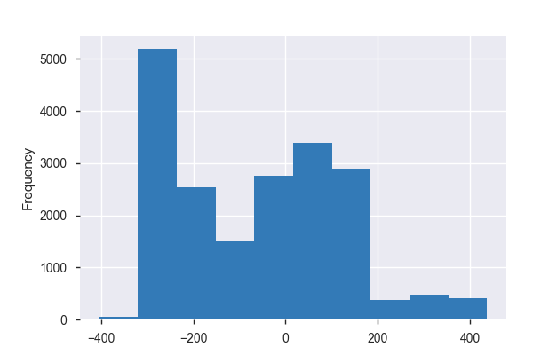

**Common Values**

| Value | Count | Frequency (%) |  |
| --- | --- | --- | --- |
| -280 | 176 | 0.9% |  |
| -277 | 173 | 0.9% |  |
| -276 | 159 | 0.8% |  |
| -289 | 156 | 0.8% |  |
| -275 | 155 | 0.8% |  |
| -278 | 154 | 0.8% |  |
| -288 | 153 | 0.8% |  |
| -279 | 140 | 0.7% |  |
| -287 | 138 | 0.7% |  |
| -274 | 121 | 0.6% |  |
| Other values (767) | 18097 | 92.2% |  |

**Extreme Values**

Minimum 5 values

| Value | Count | Frequency (%) |  |
| --- | --- | --- | --- |
| -404 | 1 | 0.0% |  |
| -383 | 1 | 0.0% |  |
| -377 | 1 | 0.0% |  |
| -371 | 1 | 0.0% |  |
| -367 | 1 | 0.0% |  |

Maximum 5 values

| Value | Count | Frequency (%) |  |
| --- | --- | --- | --- |
| 430 | 4 | 0.0% |  |
| 431 | 3 | 0.0% |  |
| 434 | 1 | 0.0% |  |
| 435 | 2 | 0.0% |  |
| 437 | 1 | 0.0% |  |

accel_arm_y  
Numeric

| Distinct count | 537 |
| --- | --- |
| Unique (%) | 2.7% |
| Missing (%) | 0.0% |
| Missing (n) | 0 |
| Infinite (%) | 0.0% |
| Infinite (n) | 0 |

| Mean | 32.597 |
| --- | --- |
| Minimum | -318 |
| Maximum | 308 |
| Zeros (%) | 0.3% |

Toggle details

**Statistics**

Quantile statistics

| Minimum | -318 |
| --- | --- |
| 5-th percentile | -134 |
| Q1 | -54 |
| Median | 14 |
| Q3 | 139 |
| 95-th percentile | 199 |
| Maximum | 308 |
| Range | 626 |
| Interquartile range | 193 |

Descriptive statistics

| Standard deviation | 109.87 |
| --- | --- |
| Coef of variation | 3.3704 |
| Kurtosis | -1.0388 |
| Mean | 32.597 |
| MAD | 95.944 |
| Skewness | 0.098234 |
| Sum | 639620 |
| Variance | 12071 |
| Memory size | 153.4 KiB |

**Histogram**

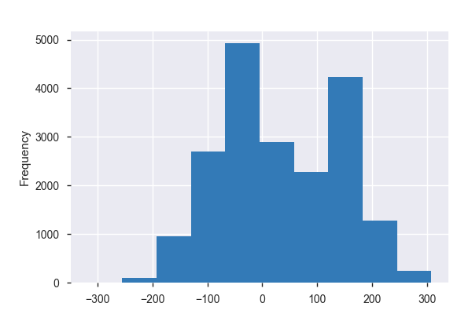

**Common Values**

| Value | Count | Frequency (%) |  |
| --- | --- | --- | --- |
| 154 | 244 | 1.2% |  |
| 155 | 214 | 1.1% |  |
| 156 | 198 | 1.0% |  |
| 111 | 178 | 0.9% |  |
| 157 | 170 | 0.9% |  |
| 158 | 167 | 0.9% |  |
| 110 | 153 | 0.8% |  |
| 153 | 141 | 0.7% |  |
| 159 | 137 | 0.7% |  |
| -44 | 127 | 0.6% |  |
| Other values (527) | 17893 | 91.2% |  |

**Extreme Values**

Minimum 5 values

| Value | Count | Frequency (%) |  |
| --- | --- | --- | --- |
| -318 | 1 | 0.0% |  |
| -315 | 1 | 0.0% |  |
| -302 | 1 | 0.0% |  |
| -301 | 1 | 0.0% |  |
| -286 | 1 | 0.0% |  |

Maximum 5 values

| Value | Count | Frequency (%) |  |
| --- | --- | --- | --- |
| 296 | 3 | 0.0% |  |
| 297 | 2 | 0.0% |  |
| 299 | 1 | 0.0% |  |
| 303 | 1 | 0.0% |  |
| 308 | 1 | 0.0% |  |

accel_arm_z  
Numeric

| Distinct count | 792 |
| --- | --- |
| Unique (%) | 4.0% |
| Missing (%) | 0.0% |
| Missing (n) | 0 |
| Infinite (%) | 0.0% |
| Infinite (n) | 0 |

| Mean | -71.245 |
| --- | --- |
| Minimum | -636 |
| Maximum | 292 |
| Zeros (%) | 0.3% |

Toggle details

**Statistics**

Quantile statistics

| Minimum | -636 |
| --- | --- |
| 5-th percentile | -340 |
| Q1 | -143 |
| Median | -47 |
| Q3 | 23 |
| 95-th percentile | 115.95 |
| Maximum | 292 |
| Range | 928 |
| Interquartile range | 166 |

Descriptive statistics

| Standard deviation | 134.65 |
| --- | --- |
| Coef of variation | -1.89 |
| Kurtosis | 0.8825 |
| Mean | -71.245 |
| MAD | 104.78 |
| Skewness | -0.8495 |
| Sum | -1397971 |
| Variance | 18131 |
| Memory size | 153.4 KiB |

**Histogram**

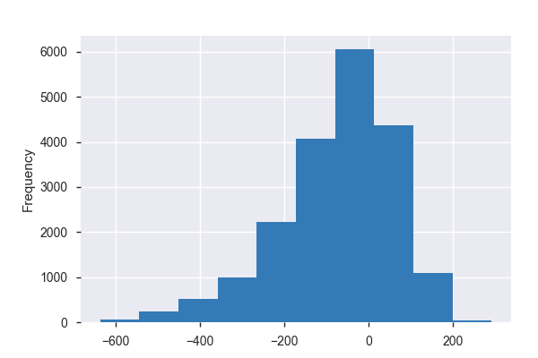

**Common Values**

| Value | Count | Frequency (%) |  |
| --- | --- | --- | --- |
| -123 | 141 | 0.7% |  |
| -122 | 125 | 0.6% |  |
| -124 | 123 | 0.6% |  |
| -28 | 112 | 0.6% |  |
| -25 | 106 | 0.5% |  |
| -23 | 105 | 0.5% |  |
| -27 | 103 | 0.5% |  |
| -30 | 102 | 0.5% |  |
| -26 | 94 | 0.5% |  |
| -184 | 93 | 0.5% |  |
| Other values (782) | 18518 | 94.4% |  |

**Extreme Values**

Minimum 5 values

| Value | Count | Frequency (%) |  |
| --- | --- | --- | --- |
| -636 | 1 | 0.0% |  |
| -630 | 1 | 0.0% |  |
| -629 | 1 | 0.0% |  |
| -613 | 1 | 0.0% |  |
| -612 | 1 | 0.0% |  |

Maximum 5 values

| Value | Count | Frequency (%) |  |
| --- | --- | --- | --- |
| 239 | 1 | 0.0% |  |
| 242 | 1 | 0.0% |  |
| 245 | 1 | 0.0% |  |
| 271 | 1 | 0.0% |  |
| 292 | 1 | 0.0% |  |

accel_belt_x  
Numeric

| Distinct count | 164 |
| --- | --- |
| Unique (%) | 0.8% |
| Missing (%) | 0.0% |
| Missing (n) | 0 |
| Infinite (%) | 0.0% |
| Infinite (n) | 0 |

| Mean | -5.5947 |
| --- | --- |
| Minimum | -120 |
| Maximum | 85 |
| Zeros (%) | 0.2% |

Toggle details

**Statistics**

Quantile statistics

| Minimum | -120 |
| --- | --- |
| 5-th percentile | -42 |
| Q1 | -21 |
| Median | -15 |
| Q3 | -5 |
| 95-th percentile | 51 |
| Maximum | 85 |
| Range | 205 |
| Interquartile range | 16 |

Descriptive statistics

| Standard deviation | 29.645 |
| --- | --- |
| Coef of variation | -5.2987 |
| Kurtosis | -0.092954 |
| Mean | -5.5947 |
| MAD | 22.572 |
| Skewness | 0.97184 |
| Sum | -109779 |
| Variance | 878.81 |
| Memory size | 153.4 KiB |

**Histogram**

[figure not shown]

**Common Values**

| Value | Count | Frequency (%) |  |
| --- | --- | --- | --- |
| -19 | 819 | 4.2% |  |
| -14 | 776 | 4.0% |  |
| -21 | 744 | 3.8% |  |
| -17 | 743 | 3.8% |  |
| -18 | 742 | 3.8% |  |
| -15 | 742 | 3.8% |  |
| -16 | 729 | 3.7% |  |
| -20 | 721 | 3.7% |  |
| -13 | 703 | 3.6% |  |
| 49 | 557 | 2.8% |  |
| Other values (154) | 12346 | 62.9% |  |

**Extreme Values**

Minimum 5 values

| Value | Count | Frequency (%) |  |
| --- | --- | --- | --- |
| -120 | 1 | 0.0% |  |
| -83 | 1 | 0.0% |  |
| -82 | 1 | 0.0% |  |
| -81 | 2 | 0.0% |  |
| -80 | 3 | 0.0% |  |

Maximum 5 values

| Value | Count | Frequency (%) |  |
| --- | --- | --- | --- |
| 78 | 3 | 0.0% |  |
| 79 | 1 | 0.0% |  |
| 81 | 1 | 0.0% |  |
| 83 | 1 | 0.0% |  |
| 85 | 1 | 0.0% |  |

accel_belt_y  
Highly correlated

*This variable is highly correlated with `avg_roll_belt` and should be ignored for analysis*

| Correlation | 0.91761 |
| --- | --- |

accel_belt_z  
Numeric

| Distinct count | 299 |
| --- | --- |
| Unique (%) | 1.5% |
| Missing (%) | 0.0% |
| Missing (n) | 0 |
| Infinite (%) | 0.0% |
| Infinite (n) | 0 |

| Mean | -72.594 |
| --- | --- |
| Minimum | -275 |
| Maximum | 105 |
| Zeros (%) | 0.1% |

Toggle details

**Statistics**

Quantile statistics

| Minimum | -275 |
| --- | --- |
| 5-th percentile | -190 |
| Q1 | -162 |
| Median | -152 |
| Q3 | 27 |
| 95-th percentile | 45 |
| Maximum | 105 |
| Range | 380 |
| Interquartile range | 189 |

Descriptive statistics

| Standard deviation | 100.45 |
| --- | --- |
| Coef of variation | -1.3837 |
| Kurtosis | -1.8346 |
| Mean | -72.594 |
| MAD | 98.721 |
| Skewness | 0.02029 |
| Sum | -1424432 |
| Variance | 10090 |
| Memory size | 153.4 KiB |

**Histogram**

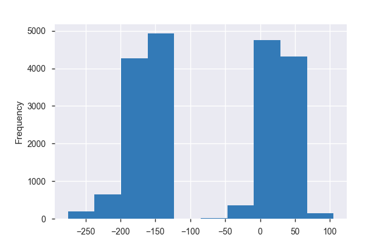

**Common Values**

| Value | Count | Frequency (%) |  |
| --- | --- | --- | --- |
| -160 | 945 | 4.8% |  |
| -159 | 876 | 4.5% |  |
| -158 | 726 | 3.7% |  |
| -161 | 707 | 3.6% |  |
| -157 | 563 | 2.9% |  |
| -162 | 460 | 2.3% |  |
| 28 | 444 | 2.3% |  |
| 22 | 437 | 2.2% |  |
| 23 | 425 | 2.2% |  |
| 27 | 413 | 2.1% |  |
| Other values (289) | 13626 | 69.4% |  |

**Extreme Values**

Minimum 5 values

| Value | Count | Frequency (%) |  |
| --- | --- | --- | --- |
| -275 | 1 | 0.0% |  |
| -269 | 1 | 0.0% |  |
| -268 | 1 | 0.0% |  |
| -266 | 3 | 0.0% |  |
| -265 | 2 | 0.0% |  |

Maximum 5 values

| Value | Count | Frequency (%) |  |
| --- | --- | --- | --- |
| 101 | 1 | 0.0% |  |
| 102 | 2 | 0.0% |  |
| 103 | 3 | 0.0% |  |
| 104 | 1 | 0.0% |  |
| 105 | 1 | 0.0% |  |

accel_dumbbell_x  
Numeric

| Distinct count | 425 |
| --- | --- |
| Unique (%) | 2.2% |
| Missing (%) | 0.0% |
| Missing (n) | 0 |
| Infinite (%) | 0.0% |
| Infinite (n) | 0 |

| Mean | -28.616 |
| --- | --- |
| Minimum | -419 |
| Maximum | 235 |
| Zeros (%) | 1.6% |

Toggle details

**Statistics**

Quantile statistics

| Minimum | -419 |
| --- | --- |
| 5-th percentile | -145 |
| Q1 | -50 |
| Median | -8 |
| Q3 | 11 |
| 95-th percentile | 53 |
| Maximum | 235 |
| Range | 654 |
| Interquartile range | 61 |

Descriptive statistics

| Standard deviation | 67.317 |
| --- | --- |
| Coef of variation | -2.3524 |
| Kurtosis | 1.0686 |
| Mean | -28.616 |
| MAD | 50.995 |
| Skewness | -0.45959 |
| Sum | -561497 |
| Variance | 4531.5 |
| Memory size | 153.4 KiB |

**Histogram**

[figure not shown]

**Common Values**

| Value | Count | Frequency (%) |  |
| --- | --- | --- | --- |
| 1 | 339 | 1.7% |  |
| -1 | 333 | 1.7% |  |
| 0 | 312 | 1.6% |  |
| 4 | 309 | 1.6% |  |
| -4 | 299 | 1.5% |  |
| 2 | 297 | 1.5% |  |
| 3 | 296 | 1.5% |  |
| -6 | 290 | 1.5% |  |
| -5 | 289 | 1.5% |  |
| -2 | 287 | 1.5% |  |
| Other values (415) | 16571 | 84.5% |  |

**Extreme Values**

Minimum 5 values

| Value | Count | Frequency (%) |  |
| --- | --- | --- | --- |
| -419 | 1 | 0.0% |  |
| -237 | 22 | 0.1% |  |
| -236 | 2 | 0.0% |  |
| -235 | 18 | 0.1% |  |
| -234 | 48 | 0.2% |  |

Maximum 5 values

| Value | Count | Frequency (%) |  |
| --- | --- | --- | --- |
| 217 | 1 | 0.0% |  |
| 219 | 2 | 0.0% |  |
| 224 | 1 | 0.0% |  |
| 234 | 1 | 0.0% |  |
| 235 | 1 | 0.0% |  |

accel_dumbbell_y  
Numeric

| Distinct count | 466 |
| --- | --- |
| Unique (%) | 2.4% |
| Missing (%) | 0.0% |
| Missing (n) | 0 |
| Infinite (%) | 0.0% |
| Infinite (n) | 0 |

| Mean | 52.633 |
| --- | --- |
| Minimum | -189 |
| Maximum | 315 |
| Zeros (%) | 0.7% |

Toggle details

**Statistics**

Quantile statistics

| Minimum | -189 |
| --- | --- |
| 5-th percentile | -61 |
| Q1 | -8 |
| Median | 41.5 |
| Q3 | 111 |
| 95-th percentile | 194 |
| Maximum | 315 |
| Range | 504 |
| Interquartile range | 119 |

Descriptive statistics

| Standard deviation | 80.751 |
| --- | --- |
| Coef of variation | 1.5342 |
| Kurtosis | -0.42934 |
| Mean | 52.633 |
| MAD | 67.209 |
| Skewness | 0.35411 |
| Sum | 1032769 |
| Variance | 6520.7 |
| Memory size | 153.4 KiB |

**Histogram**

[figure not shown]

**Common Values**

| Value | Count | Frequency (%) |  |
| --- | --- | --- | --- |
| 2 | 258 | 1.3% |  |
| 44 | 245 | 1.2% |  |
| 48 | 236 | 1.2% |  |
| -41 | 175 | 0.9% |  |
| 39 | 153 | 0.8% |  |
| -1 | 138 | 0.7% |  |
| 4 | 131 | 0.7% |  |
| 0 | 129 | 0.7% |  |
| -3 | 127 | 0.6% |  |
| 3 | 126 | 0.6% |  |
| Other values (456) | 17904 | 91.2% |  |

**Extreme Values**

Minimum 5 values

| Value | Count | Frequency (%) |  |
| --- | --- | --- | --- |
| -189 | 1 | 0.0% |  |
| -182 | 2 | 0.0% |  |
| -181 | 1 | 0.0% |  |
| -179 | 1 | 0.0% |  |
| -176 | 2 | 0.0% |  |

Maximum 5 values

| Value | Count | Frequency (%) |  |
| --- | --- | --- | --- |
| 299 | 4 | 0.0% |  |
| 300 | 1 | 0.0% |  |
| 302 | 1 | 0.0% |  |
| 310 | 1 | 0.0% |  |
| 315 | 1 | 0.0% |  |

accel_dumbbell_z  
Numeric

| Distinct count | 410 |
| --- | --- |
| Unique (%) | 2.1% |
| Missing (%) | 0.0% |
| Missing (n) | 0 |
| Infinite (%) | 0.0% |
| Infinite (n) | 0 |

| Mean | -38.322 |
| --- | --- |
| Minimum | -334 |
| Maximum | 318 |
| Zeros (%) | 0.6% |

Toggle details

**Statistics**

Quantile statistics

| Minimum | -334 |
| --- | --- |
| 5-th percentile | -206 |
| Q1 | -142 |
| Median | -1 |
| Q3 | 38 |
| 95-th percentile | 98 |
| Maximum | 318 |
| Range | 652 |
| Interquartile range | 180 |

Descriptive statistics

| Standard deviation | 109.47 |
| --- | --- |
| Coef of variation | -2.8565 |
| Kurtosis | -0.54286 |
| Mean | -38.322 |
| MAD | 95.387 |
| Skewness | -0.10052 |
| Sum | -751962 |
| Variance | 11983 |
| Memory size | 153.4 KiB |

**Histogram**

[figure not shown]

**Common Values**

| Value | Count | Frequency (%) |  |
| --- | --- | --- | --- |
| 15 | 272 | 1.4% |  |
| 6 | 240 | 1.2% |  |
| 13 | 215 | 1.1% |  |
| 81 | 210 | 1.1% |  |
| -11 | 206 | 1.0% |  |
| 10 | 205 | 1.0% |  |
| 9 | 194 | 1.0% |  |
| 11 | 190 | 1.0% |  |
| 12 | 188 | 1.0% |  |
| 14 | 184 | 0.9% |  |
| Other values (400) | 17518 | 89.3% |  |

**Extreme Values**

Minimum 5 values

| Value | Count | Frequency (%) |  |
| --- | --- | --- | --- |
| -334 | 1 | 0.0% |  |
| -319 | 1 | 0.0% |  |
| -284 | 1 | 0.0% |  |
| -273 | 3 | 0.0% |  |
| -272 | 36 | 0.2% |  |

Maximum 5 values

| Value | Count | Frequency (%) |  |
| --- | --- | --- | --- |
| 314 | 7 | 0.0% |  |
| 315 | 19 | 0.1% |  |
| 316 | 23 | 0.1% |  |
| 317 | 20 | 0.1% |  |
| 318 | 8 | 0.0% |  |

accel_forearm_x  
Numeric

| Distinct count | 794 |
| --- | --- |
| Unique (%) | 4.0% |
| Missing (%) | 0.0% |
| Missing (n) | 0 |
| Infinite (%) | 0.0% |
| Infinite (n) | 0 |

| Mean | -61.652 |
| --- | --- |
| Minimum | -498 |
| Maximum | 477 |
| Zeros (%) | 0.2% |

Toggle details

**Statistics**

Quantile statistics

| Minimum | -498 |
| --- | --- |
| 5-th percentile | -392 |
| Q1 | -178 |
| Median | -57 |
| Q3 | 76 |
| 95-th percentile | 223 |
| Maximum | 477 |
| Range | 975 |
| Interquartile range | 254 |

Descriptive statistics

| Standard deviation | 180.59 |
| --- | --- |
| Coef of variation | -2.9293 |
| Kurtosis | -0.68956 |
| Mean | -61.652 |
| MAD | 146.89 |
| Skewness | -0.2294 |
| Sum | -1209732 |
| Variance | 32614 |
| Memory size | 153.4 KiB |

**Histogram**

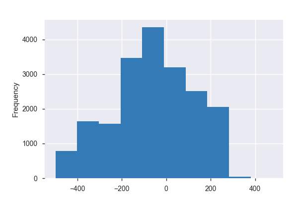

**Common Values**

| Value | Count | Frequency (%) |  |
| --- | --- | --- | --- |
| 192 | 98 | 0.5% |  |
| 193 | 87 | 0.4% |  |
| -57 | 84 | 0.4% |  |
| 191 | 79 | 0.4% |  |
| 195 | 76 | 0.4% |  |
| -55 | 72 | 0.4% |  |
| -54 | 70 | 0.4% |  |
| -56 | 68 | 0.3% |  |
| -58 | 67 | 0.3% |  |
| 194 | 67 | 0.3% |  |
| Other values (784) | 18854 | 96.1% |  |

**Extreme Values**

Minimum 5 values

| Value | Count | Frequency (%) |  |
| --- | --- | --- | --- |
| -498 | 1 | 0.0% |  |
| -496 | 1 | 0.0% |  |
| -487 | 1 | 0.0% |  |
| -479 | 1 | 0.0% |  |
| -477 | 1 | 0.0% |  |

Maximum 5 values

| Value | Count | Frequency (%) |  |
| --- | --- | --- | --- |
| 370 | 1 | 0.0% |  |
| 375 | 1 | 0.0% |  |
| 381 | 1 | 0.0% |  |
| 389 | 1 | 0.0% |  |
| 477 | 1 | 0.0% |  |

accel_forearm_y  
Numeric

| Distinct count | 1003 |
| --- | --- |
| Unique (%) | 5.1% |
| Missing (%) | 0.0% |
| Missing (n) | 0 |
| Infinite (%) | 0.0% |
| Infinite (n) | 0 |

| Mean | 163.66 |
| --- | --- |
| Minimum | -632 |
| Maximum | 923 |
| Zeros (%) | 0.2% |

Toggle details

**Statistics**

Quantile statistics

| Minimum | -632 |
| --- | --- |
| 5-th percentile | -227 |
| Q1 | 57 |
| Median | 201 |
| Q3 | 312 |
| 95-th percentile | 436 |
| Maximum | 923 |
| Range | 1555 |
| Interquartile range | 255 |

Descriptive statistics

| Standard deviation | 200.13 |
| --- | --- |
| Coef of variation | 1.2229 |
| Kurtosis | -0.11692 |
| Mean | 163.66 |
| MAD | 161.93 |
| Skewness | -0.65071 |
| Sum | 3211256 |
| Variance | 40052 |
| Memory size | 153.4 KiB |

**Histogram**

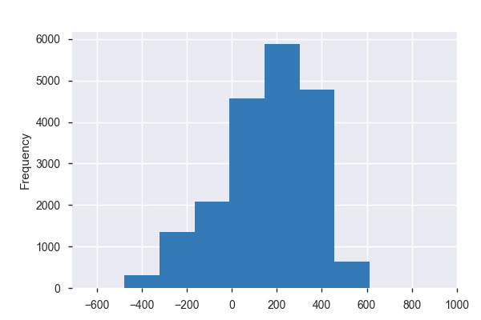

**Common Values**

| Value | Count | Frequency (%) |  |
| --- | --- | --- | --- |
| 278 | 107 | 0.5% |  |
| 279 | 101 | 0.5% |  |
| 102 | 94 | 0.5% |  |
| 99 | 87 | 0.4% |  |
| 280 | 86 | 0.4% |  |
| 100 | 85 | 0.4% |  |
| 101 | 85 | 0.4% |  |
| 203 | 82 | 0.4% |  |
| 202 | 79 | 0.4% |  |
| 107 | 77 | 0.4% |  |
| Other values (993) | 18739 | 95.5% |  |

**Extreme Values**

Minimum 5 values

| Value | Count | Frequency (%) |  |
| --- | --- | --- | --- |
| -632 | 1 | 0.0% |  |
| -595 | 1 | 0.0% |  |
| -585 | 1 | 0.0% |  |
| -537 | 1 | 0.0% |  |
| -496 | 2 | 0.0% |  |

Maximum 5 values

| Value | Count | Frequency (%) |  |
| --- | --- | --- | --- |
| 588 | 1 | 0.0% |  |
| 589 | 1 | 0.0% |  |
| 590 | 1 | 0.0% |  |
| 591 | 1 | 0.0% |  |
| 923 | 1 | 0.0% |  |

accel_forearm_z  
Numeric

| Distinct count | 580 |
| --- | --- |
| Unique (%) | 3.0% |
| Missing (%) | 0.0% |
| Missing (n) | 0 |
| Infinite (%) | 0.0% |
| Infinite (n) | 0 |

| Mean | -55.292 |
| --- | --- |
| Minimum | -446 |
| Maximum | 291 |
| Zeros (%) | 0.4% |

Toggle details

**Statistics**

Quantile statistics

| Minimum | -446 |
| --- | --- |
| 5-th percentile | -222 |
| Q1 | -182 |
| Median | -39 |
| Q3 | 26 |
| 95-th percentile | 199 |
| Maximum | 291 |
| Range | 737 |
| Interquartile range | 208 |

Descriptive statistics

| Standard deviation | 138.4 |
| --- | --- |
| Coef of variation | -2.503 |
| Kurtosis | -0.91016 |
| Mean | -55.292 |
| MAD | 120.14 |
| Skewness | 0.43649 |
| Sum | -1084938 |
| Variance | 19154 |
| Memory size | 153.4 KiB |

**Histogram**

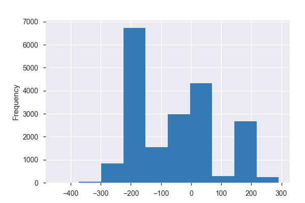

**Common Values**

| Value | Count | Frequency (%) |  |
| --- | --- | --- | --- |
| -200 | 161 | 0.8% |  |
| -201 | 160 | 0.8% |  |
| -199 | 146 | 0.7% |  |
| -202 | 143 | 0.7% |  |
| -204 | 138 | 0.7% |  |
| -203 | 134 | 0.7% |  |
| -215 | 132 | 0.7% |  |
| -214 | 128 | 0.7% |  |
| -179 | 120 | 0.6% |  |
| -168 | 120 | 0.6% |  |
| Other values (570) | 18240 | 93.0% |  |

**Extreme Values**

Minimum 5 values

| Value | Count | Frequency (%) |  |
| --- | --- | --- | --- |
| -446 | 1 | 0.0% |  |
| -410 | 1 | 0.0% |  |
| -391 | 1 | 0.0% |  |
| -386 | 1 | 0.0% |  |
| -381 | 1 | 0.0% |  |

Maximum 5 values

| Value | Count | Frequency (%) |  |
| --- | --- | --- | --- |
| 275 | 1 | 0.0% |  |
| 277 | 1 | 0.0% |  |
| 285 | 1 | 0.0% |  |
| 287 | 1 | 0.0% |  |
| 291 | 1 | 0.0% |  |

amplitude_pitch_arm  
Highly correlated

*This variable is highly correlated with `stddev_yaw_arm` and should be ignored for analysis*

| Correlation | 0.95753 |
| --- | --- |

amplitude_pitch_belt  
Numeric

| Distinct count | 14 |
| --- | --- |
| Unique (%) | 0.1% |
| Missing (%) | 97.9% |
| Missing (n) | 19216 |
| Infinite (%) | 0.0% |
| Infinite (n) | 0 |

| Mean | 2.1675 |
| --- | --- |
| Minimum | 0 |
| Maximum | 12 |
| Zeros (%) | 0.2% |

Toggle details

**Statistics**

Quantile statistics

| Minimum | 0 |
| --- | --- |
| 5-th percentile | 0 |
| Q1 | 1 |
| Median | 1 |
| Q3 | 2 |
| 95-th percentile | 8 |
| Maximum | 12 |
| Range | 12 |
| Interquartile range | 1 |

Descriptive statistics

| Standard deviation | 2.3615 |
| --- | --- |
| Coef of variation | 1.0895 |
| Kurtosis | 3.5615 |
| Mean | 2.1675 |
| MAD | 1.6425 |
| Skewness | 2.0562 |
| Sum | 880 |
| Variance | 5.5768 |
| Memory size | 153.4 KiB |

**Histogram**

[figure not shown]

**Common Values**

| Value | Count | Frequency (%) |  |
| --- | --- | --- | --- |
| 1.0 | 216 | 1.1% |  |
| 2.0 | 71 | 0.4% |  |
| 0.0 | 32 | 0.2% |  |
| 3.0 | 18 | 0.1% |  |
| 5.0 | 13 | 0.1% |  |
| 4.0 | 13 | 0.1% |  |
| 9.0 | 11 | 0.1% |  |
| 6.0 | 9 | 0.0% |  |
| 7.0 | 7 | 0.0% |  |
| 10.0 | 7 | 0.0% |  |
| Other values (3) | 9 | 0.0% |  |
| (Missing) | 19216 | 97.9% |  |

**Extreme Values**

Minimum 5 values

| Value | Count | Frequency (%) |  |
| --- | --- | --- | --- |
| 0.0 | 32 | 0.2% |  |
| 1.0 | 216 | 1.1% |  |
| 2.0 | 71 | 0.4% |  |
| 3.0 | 18 | 0.1% |  |
| 4.0 | 13 | 0.1% |  |

Maximum 5 values

| Value | Count | Frequency (%) |  |
| --- | --- | --- | --- |
| 8.0 | 7 | 0.0% |  |
| 9.0 | 11 | 0.1% |  |
| 10.0 | 7 | 0.0% |  |
| 11.0 | 1 | 0.0% |  |
| 12.0 | 1 | 0.0% |  |

amplitude_pitch_dumbbell  
Numeric

| Distinct count | 384 |
| --- | --- |
| Unique (%) | 2.0% |
| Missing (%) | 97.9% |
| Missing (n) | 19216 |
| Infinite (%) | 0.0% |
| Infinite (n) | 0 |

| Mean | 65.934 |
| --- | --- |
| Minimum | 0 |
| Maximum | 273.59 |
| Zeros (%) | 0.1% |

Toggle details

**Statistics**

Quantile statistics

| Minimum | 0 |
| --- | --- |
| 5-th percentile | 1.8875 |
| Q1 | 17.058 |
| Median | 41.725 |
| Q3 | 99.545 |
| 95-th percentile | 208.15 |
| Maximum | 273.59 |
| Range | 273.59 |
| Interquartile range | 82.487 |

Descriptive statistics

| Standard deviation | 65.234 |
| --- | --- |
| Coef of variation | 0.98938 |
| Kurtosis | 0.70579 |
| Mean | 65.934 |
| MAD | 52.446 |
| Skewness | 1.2498 |
| Sum | 26769 |
| Variance | 4255.5 |
| Memory size | 153.4 KiB |

**Histogram**

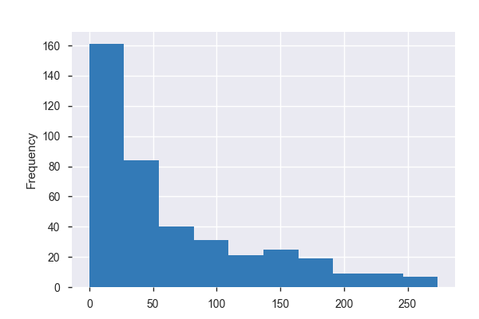

**Common Values**

| Value | Count | Frequency (%) |  |
| --- | --- | --- | --- |
| 0.0 | 16 | 0.1% |  |
| 23.88 | 2 | 0.0% |  |
| 49.62 | 2 | 0.0% |  |
| 118.4 | 2 | 0.0% |  |
| 34.63 | 2 | 0.0% |  |
| 21.76 | 2 | 0.0% |  |
| 13.45 | 2 | 0.0% |  |
| 57.39 | 2 | 0.0% |  |
| 49.57 | 2 | 0.0% |  |
| 186.22 | 1 | 0.0% |  |
| Other values (373) | 373 | 1.9% |  |
| (Missing) | 19216 | 97.9% |  |

**Extreme Values**

Minimum 5 values

| Value | Count | Frequency (%) |  |
| --- | --- | --- | --- |
| 0.0 | 16 | 0.1% |  |
| 1.02 | 1 | 0.0% |  |
| 1.15 | 1 | 0.0% |  |
| 1.27 | 1 | 0.0% |  |
| 1.39 | 1 | 0.0% |  |

Maximum 5 values

| Value | Count | Frequency (%) |  |
| --- | --- | --- | --- |
| 260.27 | 1 | 0.0% |  |
| 261.58 | 1 | 0.0% |  |
| 263.6 | 1 | 0.0% |  |
| 270.84 | 1 | 0.0% |  |
| 273.59 | 1 | 0.0% |  |

amplitude_pitch_forearm  
Numeric

| Distinct count | 184 |
| --- | --- |
| Unique (%) | 0.9% |
| Missing (%) | 97.9% |
| Missing (n) | 19216 |
| Infinite (%) | 0.0% |
| Infinite (n) | 0 |

| Mean | 139.06 |
| --- | --- |
| Minimum | 0 |
| Maximum | 360 |
| Zeros (%) | 0.4% |

Toggle details

**Statistics**

Quantile statistics

| Minimum | 0 |
| --- | --- |
| 5-th percentile | 0 |
| Q1 | 2 |
| Median | 83.7 |
| Q3 | 350 |
| 95-th percentile | 358 |
| Maximum | 360 |
| Range | 360 |
| Interquartile range | 348 |

Descriptive statistics

| Standard deviation | 147.86 |
| --- | --- |
| Coef of variation | 1.0633 |
| Kurtosis | -1.3902 |
| Mean | 139.06 |
| MAD | 131.82 |
| Skewness | 0.59579 |
| Sum | 56458 |
| Variance | 21864 |
| Memory size | 153.4 KiB |

**Histogram**

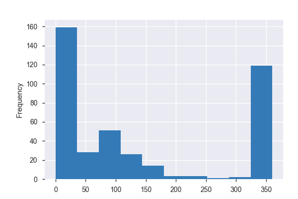

**Common Values**

| Value | Count | Frequency (%) |  |
| --- | --- | --- | --- |
| 0.0 | 85 | 0.4% |  |
| 354.0 | 26 | 0.1% |  |
| 358.0 | 13 | 0.1% |  |
| 356.0 | 13 | 0.1% |  |
| 1.0 | 12 | 0.1% |  |
| 2.0 | 11 | 0.1% |  |
| 353.0 | 11 | 0.1% |  |
| 355.0 | 9 | 0.0% |  |
| 350.0 | 9 | 0.0% |  |
| 359.0 | 9 | 0.0% |  |
| Other values (173) | 208 | 1.1% |  |
| (Missing) | 19216 | 97.9% |  |

**Extreme Values**

Minimum 5 values

| Value | Count | Frequency (%) |  |
| --- | --- | --- | --- |
| 0.0 | 85 | 0.4% |  |
| 0.3 | 1 | 0.0% |  |
| 0.7 | 1 | 0.0% |  |
| 1.0 | 12 | 0.1% |  |
| 1.3 | 1 | 0.0% |  |

Maximum 5 values

| Value | Count | Frequency (%) |  |
| --- | --- | --- | --- |
| 356.0 | 13 | 0.1% |  |
| 357.0 | 6 | 0.0% |  |
| 358.0 | 13 | 0.1% |  |
| 359.0 | 9 | 0.0% |  |
| 360.0 | 1 | 0.0% |  |

amplitude_roll_arm  
Highly correlated

*This variable is highly correlated with `stddev_pitch_arm` and should be ignored for analysis*

| Correlation | 0.98142 |
| --- | --- |

amplitude_roll_belt  
Numeric

| Distinct count | 149 |
| --- | --- |
| Unique (%) | 0.8% |
| Missing (%) | 97.9% |
| Missing (n) | 19216 |
| Infinite (%) | 0.0% |
| Infinite (n) | 0 |

| Mean | 3.7689 |
| --- | --- |
| Minimum | 0 |
| Maximum | 360 |
| Zeros (%) | 0.1% |

Toggle details

**Statistics**

Quantile statistics

| Minimum | 0 |
| --- | --- |
| 5-th percentile | 0.1 |
| Q1 | 0.3 |
| Median | 1 |
| Q3 | 2.0825 |
| 95-th percentile | 8.225 |
| Maximum | 360 |
| Range | 360 |
| Interquartile range | 1.7825 |

Descriptive statistics

| Standard deviation | 25.259 |
| --- | --- |
| Coef of variation | 6.7018 |
| Kurtosis | 195.27 |
| Mean | 3.7689 |
| MAD | 4.6529 |
| Skewness | 13.924 |
| Sum | 1530.2 |
| Variance | 637.99 |
| Memory size | 153.4 KiB |

**Histogram**

[figure not shown]

**Common Values**

| Value | Count | Frequency (%) |  |
| --- | --- | --- | --- |
| 0.2 | 40 | 0.2% |  |
| 1.0 | 31 | 0.2% |  |
| 0.3 | 27 | 0.1% |  |
| 0.1 | 26 | 0.1% |  |
| 0.5 | 18 | 0.1% |  |
| 0.4 | 18 | 0.1% |  |
| 2.0 | 14 | 0.1% |  |
| 0.7 | 14 | 0.1% |  |
| 5.0 | 13 | 0.1% |  |
| 0.0 | 12 | 0.1% |  |
| Other values (138) | 193 | 1.0% |  |
| (Missing) | 19216 | 97.9% |  |

**Extreme Values**

Minimum 5 values

| Value | Count | Frequency (%) |  |
| --- | --- | --- | --- |
| 0.0 | 12 | 0.1% |  |
| 0.1 | 26 | 0.1% |  |
| 0.13 | 1 | 0.0% |  |
| 0.2 | 40 | 0.2% |  |
| 0.3 | 27 | 0.1% |  |

Maximum 5 values

| Value | Count | Frequency (%) |  |
| --- | --- | --- | --- |
| 13.0 | 1 | 0.0% |  |
| 14.3 | 1 | 0.0% |  |
| 16.6 | 1 | 0.0% |  |
| 27.86 | 1 | 0.0% |  |
| 360.0 | 2 | 0.0% |  |

amplitude_roll_dumbbell  
Numeric

| Distinct count | 388 |
| --- | --- |
| Unique (%) | 2.0% |
| Missing (%) | 97.9% |
| Missing (n) | 19216 |
| Infinite (%) | 0.0% |
| Infinite (n) | 0 |

| Mean | 55.003 |
| --- | --- |
| Minimum | 0 |
| Maximum | 256.48 |
| Zeros (%) | 0.1% |

Toggle details

**Statistics**

Quantile statistics

| Minimum | 0 |
| --- | --- |
| 5-th percentile | 1.445 |
| Q1 | 14.967 |
| Median | 35.05 |
| Q3 | 81.043 |
| 95-th percentile | 173.49 |
| Maximum | 256.48 |
| Range | 256.48 |
| Interquartile range | 66.075 |

Descriptive statistics

| Standard deviation | 54.944 |
| --- | --- |
| Coef of variation | 0.99893 |
| Kurtosis | 1.2622 |
| Mean | 55.003 |
| MAD | 43.098 |
| Skewness | 1.376 |
| Sum | 22331 |
| Variance | 3018.8 |
| Memory size | 153.4 KiB |

**Histogram**

[figure not shown]

**Common Values**

| Value | Count | Frequency (%) |  |
| --- | --- | --- | --- |
| 0.0 | 16 | 0.1% |  |
| 2.72 | 2 | 0.0% |  |
| 20.11 | 2 | 0.0% |  |
| 19.31 | 2 | 0.0% |  |
| 29.48 | 2 | 0.0% |  |
| 3.33 | 1 | 0.0% |  |
| 9.14 | 1 | 0.0% |  |
| 134.59 | 1 | 0.0% |  |
| 148.63 | 1 | 0.0% |  |
| 35.8 | 1 | 0.0% |  |
| Other values (377) | 377 | 1.9% |  |
| (Missing) | 19216 | 97.9% |  |

**Extreme Values**

Minimum 5 values

| Value | Count | Frequency (%) |  |
| --- | --- | --- | --- |
| 0.0 | 16 | 0.1% |  |
| 0.96 | 1 | 0.0% |  |
| 1.0 | 1 | 0.0% |  |
| 1.41 | 1 | 0.0% |  |
| 1.43 | 1 | 0.0% |  |

Maximum 5 values

| Value | Count | Frequency (%) |  |
| --- | --- | --- | --- |
| 232.43 | 1 | 0.0% |  |
| 232.79 | 1 | 0.0% |  |
| 233.19 | 1 | 0.0% |  |
| 236.55 | 1 | 0.0% |  |
| 256.48 | 1 | 0.0% |  |

amplitude_roll_forearm  
Numeric

| Distinct count | 294 |
| --- | --- |
| Unique (%) | 1.5% |
| Missing (%) | 97.9% |
| Missing (n) | 19216 |
| Infinite (%) | 0.0% |
| Infinite (n) | 0 |

| Mean | 24.653 |
| --- | --- |
| Minimum | 0 |
| Maximum | 126 |
| Zeros (%) | 0.4% |

Toggle details

**Statistics**

Quantile statistics

| Minimum | 0 |
| --- | --- |
| 5-th percentile | 0 |
| Q1 | 1.125 |
| Median | 17.77 |
| Q3 | 39.875 |
| 95-th percentile | 73.525 |
| Maximum | 126 |
| Range | 126 |
| Interquartile range | 38.75 |

Descriptive statistics

| Standard deviation | 25.885 |
| --- | --- |
| Coef of variation | 1.05 |
| Kurtosis | 1.2404 |
| Mean | 24.653 |
| MAD | 20.847 |
| Skewness | 1.1937 |
| Sum | 10009 |
| Variance | 670.03 |
| Memory size | 153.4 KiB |

**Histogram**

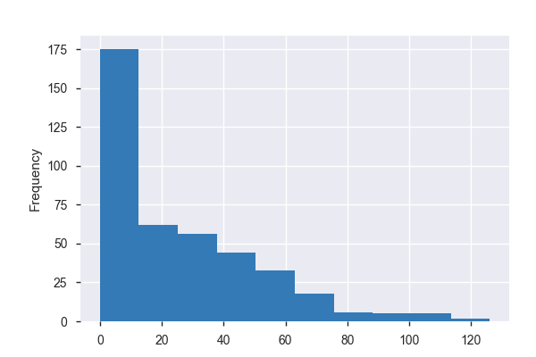

**Common Values**

| Value | Count | Frequency (%) |  |
| --- | --- | --- | --- |
| 0.0 | 83 | 0.4% |  |
| 1.7 | 4 | 0.0% |  |
| 1.0 | 3 | 0.0% |  |
| 0.3 | 3 | 0.0% |  |
| 6.8 | 3 | 0.0% |  |
| 2.7 | 3 | 0.0% |  |
| 3.7 | 2 | 0.0% |  |
| 27.7 | 2 | 0.0% |  |
| 32.7 | 2 | 0.0% |  |
| 2.3 | 2 | 0.0% |  |
| Other values (283) | 299 | 1.5% |  |
| (Missing) | 19216 | 97.9% |  |

**Extreme Values**

Minimum 5 values

| Value | Count | Frequency (%) |  |
| --- | --- | --- | --- |
| 0.0 | 83 | 0.4% |  |
| 0.04 | 1 | 0.0% |  |
| 0.2 | 1 | 0.0% |  |
| 0.3 | 3 | 0.0% |  |
| 0.5 | 1 | 0.0% |  |

Maximum 5 values

| Value | Count | Frequency (%) |  |
| --- | --- | --- | --- |
| 108.1 | 1 | 0.0% |  |
| 108.2 | 1 | 0.0% |  |
| 112.1 | 1 | 0.0% |  |
| 120.3 | 1 | 0.0% |  |
| 126.0 | 1 | 0.0% |  |

amplitude_yaw_arm  
Numeric

| Distinct count | 52 |
| --- | --- |
| Unique (%) | 0.3% |
| Missing (%) | 97.9% |
| Missing (n) | 19216 |
| Infinite (%) | 0.0% |
| Infinite (n) | 0 |

| Mean | 20.791 |
| --- | --- |
| Minimum | 0 |
| Maximum | 52 |
| Zeros (%) | 0.1% |

Toggle details

**Statistics**

Quantile statistics

| Minimum | 0 |
| --- | --- |
| 5-th percentile | 1 |
| Q1 | 13 |
| Median | 22 |
| Q3 | 28.75 |
| 95-th percentile | 41 |
| Maximum | 52 |
| Range | 52 |
| Interquartile range | 15.75 |

Descriptive statistics

| Standard deviation | 12.277 |
| --- | --- |
| Coef of variation | 0.59051 |
| Kurtosis | -0.60481 |
| Mean | 20.791 |
| MAD | 9.769 |
| Skewness | 0.035252 |
| Sum | 8441 |
| Variance | 150.73 |
| Memory size | 153.4 KiB |

**Histogram**

[figure not shown]

**Common Values**

| Value | Count | Frequency (%) |  |
| --- | --- | --- | --- |
| 1.0 | 28 | 0.1% |  |
| 22.0 | 27 | 0.1% |  |
| 21.0 | 18 | 0.1% |  |
| 25.0 | 17 | 0.1% |  |
| 24.0 | 17 | 0.1% |  |
| 26.0 | 15 | 0.1% |  |
| 20.0 | 15 | 0.1% |  |
| 32.0 | 13 | 0.1% |  |
| 19.0 | 12 | 0.1% |  |
| 18.0 | 12 | 0.1% |  |
| Other values (41) | 232 | 1.2% |  |
| (Missing) | 19216 | 97.9% |  |

**Extreme Values**

Minimum 5 values

| Value | Count | Frequency (%) |  |
| --- | --- | --- | --- |
| 0.0 | 11 | 0.1% |  |
| 1.0 | 28 | 0.1% |  |
| 2.0 | 9 | 0.0% |  |
| 3.0 | 9 | 0.0% |  |
| 4.0 | 4 | 0.0% |  |

Maximum 5 values

| Value | Count | Frequency (%) |  |
| --- | --- | --- | --- |
| 46.0 | 4 | 0.0% |  |
| 48.0 | 1 | 0.0% |  |
| 50.0 | 1 | 0.0% |  |
| 51.0 | 1 | 0.0% |  |
| 52.0 | 1 | 0.0% |  |

amplitude_yaw_belt  
Categorical

| Distinct count | 4 |
| --- | --- |
| Unique (%) | 0.0% |
| Missing (%) | 97.9% |
| Missing (n) | 19216 |

| 0.0000 | 384 |
| --- | --- |
| 0.00 | 12 |
| #DIV/0! | 10 |
| (Missing) | 19216 |

Toggle details

| Value | Count | Frequency (%) |  |
| --- | --- | --- | --- |
| 0.0000 | 384 | 2.0% |  |
| 0.00 | 12 | 0.1% |  |
| #DIV/0! | 10 | 0.1% |  |
| (Missing) | 19216 | 97.9% |  |

amplitude_yaw_dumbbell  
Categorical

| Distinct count | 3 |
| --- | --- |
| Unique (%) | 0.0% |
| Missing (%) | 97.9% |
| Missing (n) | 19216 |

| 0.00 | 401 |
| --- | --- |
| #DIV/0! | 5 |
| (Missing) | 19216 |

Toggle details

| Value | Count | Frequency (%) |  |
| --- | --- | --- | --- |
| 0.00 | 401 | 2.0% |  |
| #DIV/0! | 5 | 0.0% |  |
| (Missing) | 19216 | 97.9% |  |

amplitude_yaw_forearm  
Categorical

| Distinct count | 3 |
| --- | --- |
| Unique (%) | 0.0% |
| Missing (%) | 97.9% |
| Missing (n) | 19216 |

| 0.00 | 322 |
| --- | --- |
| #DIV/0! | 84 |
| (Missing) | 19216 |

Toggle details

| Value | Count | Frequency (%) |  |
| --- | --- | --- | --- |
| 0.00 | 322 | 1.6% |  |
| #DIV/0! | 84 | 0.4% |  |
| (Missing) | 19216 | 97.9% |  |

avg_pitch_arm  
Numeric

| Distinct count | 331 |
| --- | --- |
| Unique (%) | 1.7% |
| Missing (%) | 97.9% |
| Missing (n) | 19216 |
| Infinite (%) | 0.0% |
| Infinite (n) | 0 |

| Mean | -4.901 |
| --- | --- |
| Minimum | -81.773 |
| Maximum | 75.659 |
| Zeros (%) | 0.4% |

Toggle details

**Statistics**

Quantile statistics

| Minimum | -81.773 |
| --- | --- |
| 5-th percentile | -48.627 |
| Q1 | -22.77 |
| Median | 0 |
| Q3 | 8.2768 |
| 95-th percentile | 43.065 |
| Maximum | 75.659 |
| Range | 157.43 |
| Interquartile range | 31.047 |

Descriptive statistics

| Standard deviation | 26.835 |
| --- | --- |
| Coef of variation | -5.4754 |
| Kurtosis | 0.55923 |
| Mean | -4.901 |
| MAD | 20.337 |
| Skewness | 0.19684 |
| Sum | -1989.8 |
| Variance | 720.11 |
| Memory size | 153.4 KiB |

**Histogram**

[figure not shown]

**Common Values**

| Value | Count | Frequency (%) |  |
| --- | --- | --- | --- |
| 0.0 | 77 | 0.4% |  |
| -28.3238 | 1 | 0.0% |  |
| -36.2407 | 1 | 0.0% |  |
| -5.478 | 1 | 0.0% |  |
| 21.4327 | 1 | 0.0% |  |
| -16.4085 | 1 | 0.0% |  |
| -30.9564 | 1 | 0.0% |  |
| 19.0611 | 1 | 0.0% |  |
| -73.0633 | 1 | 0.0% |  |
| 0.7296 | 1 | 0.0% |  |
| Other values (320) | 320 | 1.6% |  |
| (Missing) | 19216 | 97.9% |  |

**Extreme Values**

Minimum 5 values

| Value | Count | Frequency (%) |  |
| --- | --- | --- | --- |
| -81.7727 | 1 | 0.0% |  |
| -77.01899999999999 | 1 | 0.0% |  |
| -73.2163 | 1 | 0.0% |  |
| -73.0633 | 1 | 0.0% |  |
| -72.8 | 1 | 0.0% |  |

Maximum 5 values

| Value | Count | Frequency (%) |  |
| --- | --- | --- | --- |
| 68.9884 | 1 | 0.0% |  |
| 69.4786 | 1 | 0.0% |  |
| 69.6479 | 1 | 0.0% |  |
| 70.7026 | 1 | 0.0% |  |
| 75.6591 | 1 | 0.0% |  |

avg_pitch_belt  
Highly correlated

*This variable is highly correlated with `pitch_belt` and should be ignored for analysis*

| Correlation | 0.9985 |
| --- | --- |

avg_pitch_dumbbell  
Numeric

| Distinct count | 398 |
| --- | --- |
| Unique (%) | 2.0% |
| Missing (%) | 97.9% |
| Missing (n) | 19216 |
| Infinite (%) | 0.0% |
| Infinite (n) | 0 |

| Mean | -12.334 |
| --- | --- |
| Minimum | -70.735 |
| Maximum | 94.276 |
| Zeros (%) | 0.0% |

Toggle details

**Statistics**

Quantile statistics

| Minimum | -70.735 |
| --- | --- |
| 5-th percentile | -53.016 |
| Q1 | -41.999 |
| Median | -19.905 |
| Q3 | 13.207 |
| 95-th percentile | 39.869 |
| Maximum | 94.276 |
| Range | 165.01 |
| Interquartile range | 55.206 |

Descriptive statistics

| Standard deviation | 32.064 |
| --- | --- |
| Coef of variation | -2.5997 |
| Kurtosis | -0.44963 |
| Mean | -12.334 |
| MAD | 27.29 |
| Skewness | 0.4884 |
| Sum | -5007.5 |
| Variance | 1028.1 |
| Memory size | 153.4 KiB |

**Histogram**

[figure not shown]

**Common Values**

| Value | Count | Frequency (%) |  |
| --- | --- | --- | --- |
| 16.8326 | 3 | 0.0% |  |
| 27.1869 | 3 | 0.0% |  |
| -38.2221 | 3 | 0.0% |  |
| -61.3062 | 2 | 0.0% |  |
| -43.9609 | 2 | 0.0% |  |
| 41.5322 | 2 | 0.0% |  |
| -49.8594 | 1 | 0.0% |  |
| -46.933 | 1 | 0.0% |  |
| 4.4254 | 1 | 0.0% |  |
| 39.4174 | 1 | 0.0% |  |
| Other values (387) | 387 | 2.0% |  |
| (Missing) | 19216 | 97.9% |  |

**Extreme Values**

Minimum 5 values

| Value | Count | Frequency (%) |  |
| --- | --- | --- | --- |
| -70.7346 | 1 | 0.0% |  |
| -70.5253 | 1 | 0.0% |  |
| -70.4565 | 1 | 0.0% |  |
| -63.1127 | 1 | 0.0% |  |
| -61.3062 | 2 | 0.0% |  |

Maximum 5 values

| Value | Count | Frequency (%) |  |
| --- | --- | --- | --- |
| 62.0236 | 1 | 0.0% |  |
| 79.7193 | 1 | 0.0% |  |
| 82.2125 | 1 | 0.0% |  |
| 93.9297 | 1 | 0.0% |  |
| 94.2764 | 1 | 0.0% |  |

avg_pitch_forearm  
Numeric

| Distinct count | 325 |
| --- | --- |
| Unique (%) | 1.7% |
| Missing (%) | 97.9% |
| Missing (n) | 19216 |
| Infinite (%) | 0.0% |
| Infinite (n) | 0 |

| Mean | 11.795 |
| --- | --- |
| Minimum | -68.167 |
| Maximum | 72.091 |
| Zeros (%) | 0.4% |

Toggle details

**Statistics**

Quantile statistics

| Minimum | -68.167 |
| --- | --- |
| 5-th percentile | -44.501 |
| Q1 | 0 |
| Median | 12.017 |
| Q3 | 28.475 |
| 95-th percentile | 47.696 |
| Maximum | 72.091 |
| Range | 140.26 |
| Interquartile range | 28.475 |

Descriptive statistics

| Standard deviation | 24.834 |
| --- | --- |
| Coef of variation | 2.1055 |
| Kurtosis | 2.0362 |
| Mean | 11.795 |
| MAD | 17.91 |
| Skewness | -0.90468 |
| Sum | 4788.8 |
| Variance | 616.72 |
| Memory size | 153.4 KiB |

**Histogram**

[figure not shown]

**Common Values**

| Value | Count | Frequency (%) |  |
| --- | --- | --- | --- |
| 0.0 | 83 | 0.4% |  |
| 29.285 | 1 | 0.0% |  |
| 21.401139999999998 | 1 | 0.0% |  |
| -58.50233000000001 | 1 | 0.0% |  |
| 7.1898 | 1 | 0.0% |  |
| 30.69412 | 1 | 0.0% |  |
| 18.63429 | 1 | 0.0% |  |
| -17.51905 | 1 | 0.0% |  |
| 48.82439 | 1 | 0.0% |  |
| -0.59022 | 1 | 0.0% |  |
| Other values (314) | 314 | 1.6% |  |
| (Missing) | 19216 | 97.9% |  |

**Extreme Values**

Minimum 5 values

| Value | Count | Frequency (%) |  |
| --- | --- | --- | --- |
| -68.16735 | 1 | 0.0% |  |
| -65.51857 | 1 | 0.0% |  |
| -65.4625 | 1 | 0.0% |  |
| -65.25385 | 1 | 0.0% |  |
| -64.95517 | 1 | 0.0% |  |

Maximum 5 values

| Value | Count | Frequency (%) |  |
| --- | --- | --- | --- |
| 62.81276999999999 | 1 | 0.0% |  |
| 68.16818 | 1 | 0.0% |  |
| 68.50909 | 1 | 0.0% |  |
| 70.15385 | 1 | 0.0% |  |
| 72.0913 | 1 | 0.0% |  |

avg_roll_arm  
Highly correlated

*This variable is highly correlated with `roll_arm` and should be ignored for analysis*

| Correlation | 0.91276 |
| --- | --- |

avg_roll_belt  
Highly correlated

*This variable is highly correlated with `min_pitch_belt` and should be ignored for analysis*

| Correlation | 0.98396 |
| --- | --- |

avg_roll_dumbbell  
Numeric

| Distinct count | 398 |
| --- | --- |
| Unique (%) | 2.0% |
| Missing (%) | 97.9% |
| Missing (n) | 19216 |
| Infinite (%) | 0.0% |
| Infinite (n) | 0 |

| Mean | 23.864 |
| --- | --- |
| Minimum | -128.96 |
| Maximum | 125.99 |
| Zeros (%) | 0.0% |

Toggle details

**Statistics**

Quantile statistics

| Minimum | -128.96 |
| --- | --- |
| 5-th percentile | -102.64 |
| Q1 | -12.326 |
| Median | 48.231 |
| Q3 | 64.374 |
| 95-th percentile | 108.36 |
| Maximum | 125.99 |
| Range | 254.96 |
| Interquartile range | 76.701 |

Descriptive statistics

| Standard deviation | 62.904 |
| --- | --- |
| Coef of variation | 2.6359 |
| Kurtosis | -0.44512 |
| Mean | 23.864 |
| MAD | 52.202 |
| Skewness | -0.75761 |
| Sum | 9689 |
| Variance | 3956.9 |
| Memory size | 153.4 KiB |

**Histogram**

[figure not shown]

**Common Values**

| Value | Count | Frequency (%) |  |
| --- | --- | --- | --- |
| 125.9932 | 3 | 0.0% |  |
| 52.66 | 3 | 0.0% |  |
| -101.5169 | 3 | 0.0% |  |
| -107.4901 | 2 | 0.0% |  |
| 11.8579 | 2 | 0.0% |  |
| 109.2254 | 2 | 0.0% |  |
| 51.6648 | 1 | 0.0% |  |
| 60.7889 | 1 | 0.0% |  |
| 59.0769 | 1 | 0.0% |  |
| -12.4734 | 1 | 0.0% |  |
| Other values (387) | 387 | 2.0% |  |
| (Missing) | 19216 | 97.9% |  |

**Extreme Values**

Minimum 5 values

| Value | Count | Frequency (%) |  |
| --- | --- | --- | --- |
| -128.963 | 1 | 0.0% |  |
| -117.7838 | 1 | 0.0% |  |
| -117.0223 | 1 | 0.0% |  |
| -114.4985 | 1 | 0.0% |  |
| -110.9328 | 1 | 0.0% |  |

Maximum 5 values

| Value | Count | Frequency (%) |  |
| --- | --- | --- | --- |
| 112.9621 | 1 | 0.0% |  |
| 115.0085 | 1 | 0.0% |  |
| 117.7984 | 1 | 0.0% |  |
| 121.8832 | 1 | 0.0% |  |
| 125.9932 | 3 | 0.0% |  |

avg_roll_forearm  
Numeric

| Distinct count | 323 |
| --- | --- |
| Unique (%) | 1.6% |
| Missing (%) | 97.9% |
| Missing (n) | 19216 |
| Infinite (%) | 0.0% |
| Infinite (n) | 0 |

| Mean | 33.165 |
| --- | --- |
| Minimum | -177.23 |
| Maximum | 177.26 |
| Zeros (%) | 0.4% |

Toggle details

**Statistics**

Quantile statistics

| Minimum | -177.23 |
| --- | --- |
| 5-th percentile | -97.621 |
| Q1 | -0.90872 |
| Median | 11.172 |
| Q3 | 107.13 |
| 95-th percentile | 152.48 |
| Maximum | 177.26 |
| Range | 354.49 |
| Interquartile range | 108.04 |

Descriptive statistics

| Standard deviation | 79.52 |
| --- | --- |
| Coef of variation | 2.3977 |
| Kurtosis | -0.31736 |
| Mean | 33.165 |
| MAD | 64.814 |
| Skewness | -0.13899 |
| Sum | 13465 |
| Variance | 6323.5 |
| Memory size | 153.4 KiB |

**Histogram**

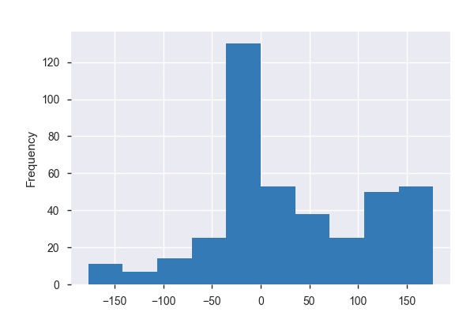

**Common Values**

| Value | Count | Frequency (%) |  |
| --- | --- | --- | --- |
| 0.0 | 83 | 0.4% |  |
| 148.0 | 3 | 0.0% |  |
| 35.21951 | 1 | 0.0% |  |
| 22.73171 | 1 | 0.0% |  |
| 55.584469999999996 | 1 | 0.0% |  |
| 133.81633 | 1 | 0.0% |  |
| 151.91488999999999 | 1 | 0.0% |  |
| 104.02128 | 1 | 0.0% |  |
| 137.78333 | 1 | 0.0% |  |
| 130.82051 | 1 | 0.0% |  |
| Other values (312) | 312 | 1.6% |  |
| (Missing) | 19216 | 97.9% |  |

**Extreme Values**

Minimum 5 values

| Value | Count | Frequency (%) |  |
| --- | --- | --- | --- |
| -177.23404 | 1 | 0.0% |  |
| -177.13043000000002 | 1 | 0.0% |  |
| -177.11111 | 1 | 0.0% |  |
| -176.2439 | 1 | 0.0% |  |
| -174.13043000000002 | 1 | 0.0% |  |

Maximum 5 values

| Value | Count | Frequency (%) |  |
| --- | --- | --- | --- |
| 166.45 | 1 | 0.0% |  |
| 167.23529 | 1 | 0.0% |  |
| 174.71428999999998 | 1 | 0.0% |  |
| 177.12121000000002 | 1 | 0.0% |  |
| 177.25641000000002 | 1 | 0.0% |  |

avg_yaw_arm  
Numeric

| Distinct count | 331 |
| --- | --- |
| Unique (%) | 1.7% |
| Missing (%) | 97.9% |
| Missing (n) | 19216 |
| Infinite (%) | 0.0% |
| Infinite (n) | 0 |

| Mean | 2.3586 |
| --- | --- |
| Minimum | -173.44 |
| Maximum | 152 |
| Zeros (%) | 0.4% |

Toggle details

**Statistics**

Quantile statistics

| Minimum | -173.44 |
| --- | --- |
| 5-th percentile | -92.687 |
| Q1 | -29.198 |
| Median | 0 |
| Q3 | 38.185 |
| 95-th percentile | 107.15 |
| Maximum | 152 |
| Range | 325.44 |
| Interquartile range | 67.382 |

Descriptive statistics

| Standard deviation | 61.327 |
| --- | --- |
| Coef of variation | 26.001 |
| Kurtosis | 0.34708 |
| Mean | 2.3586 |
| MAD | 44.872 |
| Skewness | -0.12633 |
| Sum | 957.6 |
| Variance | 3761 |
| Memory size | 153.4 KiB |

**Histogram**

[figure not shown]

**Common Values**

| Value | Count | Frequency (%) |  |
| --- | --- | --- | --- |
| 0.0 | 77 | 0.4% |  |
| -17.3071 | 1 | 0.0% |  |
| -80.393 | 1 | 0.0% |  |
| -67.4047 | 1 | 0.0% |  |
| -75.8442 | 1 | 0.0% |  |
| -92.8271 | 1 | 0.0% |  |
| -69.5071 | 1 | 0.0% |  |
| 29.0589 | 1 | 0.0% |  |
| 29.4498 | 1 | 0.0% |  |
| -136.4286 | 1 | 0.0% |  |
| Other values (320) | 320 | 1.6% |  |
| (Missing) | 19216 | 97.9% |  |

**Extreme Values**

Minimum 5 values

| Value | Count | Frequency (%) |  |
| --- | --- | --- | --- |
| -173.44 | 1 | 0.0% |  |
| -173.2826 | 1 | 0.0% |  |
| -167.8636 | 1 | 0.0% |  |
| -164.6389 | 1 | 0.0% |  |
| -162.0 | 1 | 0.0% |  |

Maximum 5 values

| Value | Count | Frequency (%) |  |
| --- | --- | --- | --- |
| 137.9933 | 1 | 0.0% |  |
| 140.8913 | 1 | 0.0% |  |
| 142.3103 | 1 | 0.0% |  |
| 150.4583 | 1 | 0.0% |  |
| 152.0 | 1 | 0.0% |  |

avg_yaw_belt  
Highly correlated

*This variable is highly correlated with `min_roll_belt` and should be ignored for analysis*

| Correlation | 0.99367 |
| --- | --- |

avg_yaw_dumbbell  
Highly correlated

*This variable is highly correlated with `max_picth_dumbbell` and should be ignored for analysis*

| Correlation | 0.93838 |
| --- | --- |

avg_yaw_forearm  
Numeric

| Distinct count | 325 |
| --- | --- |
| Unique (%) | 1.7% |
| Missing (%) | 97.9% |
| Missing (n) | 19216 |
| Infinite (%) | 0.0% |
| Infinite (n) | 0 |

| Mean | 17.998 |
| --- | --- |
| Minimum | -155.06 |
| Maximum | 169.24 |
| Zeros (%) | 0.4% |

Toggle details

**Statistics**

Quantile statistics

| Minimum | -155.06 |
| --- | --- |
| 5-th percentile | -110.7 |
| Q1 | -26.258 |
| Median | 0 |
| Q3 | 85.794 |
| 95-th percentile | 133.06 |
| Maximum | 169.24 |
| Range | 324.3 |
| Interquartile range | 112.05 |

Descriptive statistics

| Standard deviation | 77.559 |
| --- | --- |
| Coef of variation | 4.3092 |
| Kurtosis | -0.65448 |
| Mean | 17.998 |
| MAD | 63.484 |
| Skewness | -0.13763 |
| Sum | 7307.3 |
| Variance | 6015.4 |
| Memory size | 153.4 KiB |

**Histogram**

[figure not shown]

**Common Values**

| Value | Count | Frequency (%) |  |
| --- | --- | --- | --- |
| 0.0 | 83 | 0.4% |  |
| -21.364710000000002 | 1 | 0.0% |  |
| -13.86614 | 1 | 0.0% |  |
| -8.844439999999999 | 1 | 0.0% |  |
| -138.56818 | 1 | 0.0% |  |
| -20.25641 | 1 | 0.0% |  |
| 126.42857 | 1 | 0.0% |  |
| -32.54773 | 1 | 0.0% |  |
| 103.42222 | 1 | 0.0% |  |
| -77.34222 | 1 | 0.0% |  |
| Other values (314) | 314 | 1.6% |  |
| (Missing) | 19216 | 97.9% |  |

**Extreme Values**

Minimum 5 values

| Value | Count | Frequency (%) |  |
| --- | --- | --- | --- |
| -155.06 | 1 | 0.0% |  |
| -154.79545 | 1 | 0.0% |  |
| -153.08163000000002 | 1 | 0.0% |  |
| -151.44898 | 1 | 0.0% |  |
| -150.03922 | 1 | 0.0% |  |

Maximum 5 values

| Value | Count | Frequency (%) |  |
| --- | --- | --- | --- |
| 165.70588 | 1 | 0.0% |  |
| 165.97871999999998 | 1 | 0.0% |  |
| 167.32558 | 1 | 0.0% |  |
| 168.85714 | 1 | 0.0% |  |
| 169.24138 | 1 | 0.0% |  |

cvtd_timestamp  
Date

| Distinct count | 20 |
| --- | --- |
| Unique (%) | 0.1% |
| Missing (%) | 0.0% |
| Missing (n) | 0 |
| Infinite (%) | 0.0% |
| Infinite (n) | 0 |

| Minimum | 2011-02-12 13:32:00 |
| --- | --- |
| Maximum | 2011-11-30 17:12:00 |

Toggle details

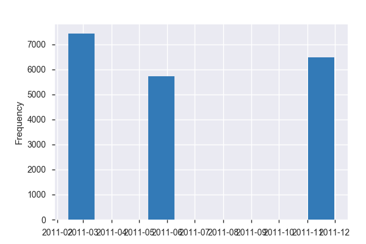

gyros_arm_x  
Numeric

| Distinct count | 643 |
| --- | --- |
| Unique (%) | 3.3% |
| Missing (%) | 0.0% |
| Missing (n) | 0 |
| Infinite (%) | 0.0% |
| Infinite (n) | 0 |

| Mean | 0.042772 |
| --- | --- |
| Minimum | -6.37 |
| Maximum | 4.87 |
| Zeros (%) | 2.6% |

Toggle details

**Statistics**

Quantile statistics

| Minimum | -6.37 |
| --- | --- |
| 5-th percentile | -3.48 |
| Q1 | -1.33 |
| Median | 0.08 |
| Q3 | 1.57 |
| 95-th percentile | 3.12 |
| Maximum | 4.87 |
| Range | 11.24 |
| Interquartile range | 2.9 |

Descriptive statistics

| Standard deviation | 1.9936 |
| --- | --- |
| Coef of variation | 46.609 |
| Kurtosis | -0.43074 |
| Mean | 0.042772 |
| MAD | 1.5593 |
| Skewness | -0.28774 |
| Sum | 839.28 |
| Variance | 3.9744 |
| Memory size | 153.4 KiB |

**Histogram**

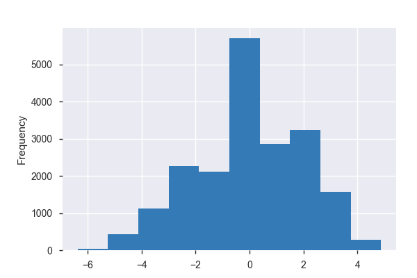

**Common Values**

| Value | Count | Frequency (%) |  |
| --- | --- | --- | --- |
| 0.02 | 524 | 2.7% |  |
| 0.0 | 516 | 2.6% |  |
| -0.02 | 355 | 1.8% |  |
| 0.03 | 238 | 1.2% |  |
| 0.26 | 187 | 1.0% |  |
| 0.27 | 170 | 0.9% |  |
| -0.03 | 167 | 0.9% |  |
| 0.05 | 152 | 0.8% |  |
| 0.24 | 150 | 0.8% |  |
| 0.29 | 133 | 0.7% |  |
| Other values (633) | 17030 | 86.8% |  |

**Extreme Values**

Minimum 5 values

| Value | Count | Frequency (%) |  |
| --- | --- | --- | --- |
| -6.37 | 2 | 0.0% |  |
| -6.36 | 1 | 0.0% |  |
| -6.34 | 1 | 0.0% |  |
| -6.13 | 1 | 0.0% |  |
| -6.12 | 1 | 0.0% |  |

Maximum 5 values

| Value | Count | Frequency (%) |  |
| --- | --- | --- | --- |
| 4.7 | 1 | 0.0% |  |
| 4.74 | 1 | 0.0% |  |
| 4.78 | 1 | 0.0% |  |
| 4.82 | 1 | 0.0% |  |
| 4.87 | 3 | 0.0% |  |

gyros_arm_y  
Numeric

| Distinct count | 376 |
| --- | --- |
| Unique (%) | 1.9% |
| Missing (%) | 0.0% |
| Missing (n) | 0 |
| Infinite (%) | 0.0% |
| Infinite (n) | 0 |

| Mean | -0.25708 |
| --- | --- |
| Minimum | -3.44 |
| Maximum | 2.84 |
| Zeros (%) | 2.6% |

Toggle details

**Statistics**

Quantile statistics

| Minimum | -3.44 |
| --- | --- |
| 5-th percentile | -1.56 |
| Q1 | -0.8 |
| Median | -0.24 |
| Q3 | 0.14 |
| 95-th percentile | 1.27 |
| Maximum | 2.84 |
| Range | 6.28 |
| Interquartile range | 0.94 |

Descriptive statistics

| Standard deviation | 0.85139 |
| --- | --- |
| Coef of variation | -3.3118 |
| Kurtosis | 0.64695 |
| Mean | -0.25708 |
| MAD | 0.65295 |
| Skewness | 0.13523 |
| Sum | -5044.4 |
| Variance | 0.72487 |
| Memory size | 153.4 KiB |

**Histogram**

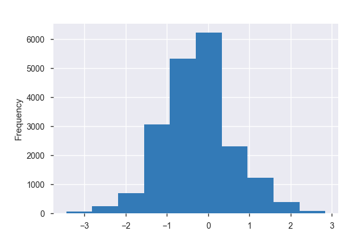

**Common Values**

| Value | Count | Frequency (%) |  |
| --- | --- | --- | --- |
| -0.02 | 749 | 3.8% |  |
| 0.0 | 515 | 2.6% |  |
| -0.03 | 474 | 2.4% |  |
| -0.05 | 302 | 1.5% |  |
| 0.02 | 293 | 1.5% |  |
| -0.5 | 279 | 1.4% |  |
| -0.51 | 249 | 1.3% |  |
| -0.53 | 226 | 1.2% |  |
| -0.56 | 203 | 1.0% |  |
| -0.06 | 198 | 1.0% |  |
| Other values (366) | 16134 | 82.2% |  |

**Extreme Values**

Minimum 5 values

| Value | Count | Frequency (%) |  |
| --- | --- | --- | --- |
| -3.44 | 1 | 0.0% |  |
| -3.4 | 1 | 0.0% |  |
| -3.37 | 1 | 0.0% |  |
| -3.32 | 1 | 0.0% |  |
| -3.29 | 1 | 0.0% |  |

Maximum 5 values

| Value | Count | Frequency (%) |  |
| --- | --- | --- | --- |
| 2.76 | 2 | 0.0% |  |
| 2.78 | 1 | 0.0% |  |
| 2.79 | 2 | 0.0% |  |
| 2.81 | 2 | 0.0% |  |
| 2.84 | 1 | 0.0% |  |

gyros_arm_z  
Numeric

| Distinct count | 248 |
| --- | --- |
| Unique (%) | 1.3% |
| Missing (%) | 0.0% |
| Missing (n) | 0 |
| Infinite (%) | 0.0% |
| Infinite (n) | 0 |

| Mean | 0.26948 |
| --- | --- |
| Minimum | -2.33 |
| Maximum | 3.02 |
| Zeros (%) | 2.7% |

Toggle details

**Statistics**

Quantile statistics

| Minimum | -2.33 |
| --- | --- |
| 5-th percentile | -0.67 |
| Q1 | -0.07 |
| Median | 0.23 |
| Q3 | 0.72 |
| 95-th percentile | 1.1 |
| Maximum | 3.02 |
| Range | 5.35 |
| Interquartile range | 0.79 |

Descriptive statistics

| Standard deviation | 0.55317 |
| --- | --- |
| Coef of variation | 2.0527 |
| Kurtosis | 0.04186 |
| Mean | 0.26948 |
| MAD | 0.45575 |
| Skewness | -0.17071 |
| Sum | 5287.7 |
| Variance | 0.306 |
| Memory size | 153.4 KiB |

**Histogram**

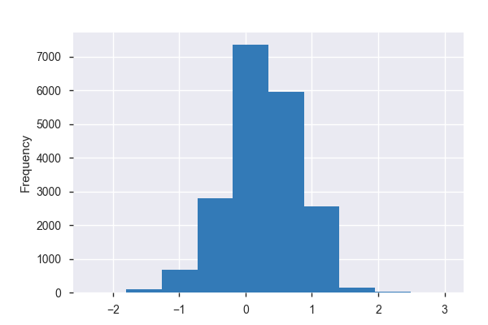

**Common Values**

| Value | Count | Frequency (%) |  |
| --- | --- | --- | --- |
| -0.02 | 582 | 3.0% |  |
| 0.0 | 524 | 2.7% |  |
| -0.03 | 392 | 2.0% |  |
| 0.02 | 373 | 1.9% |  |
| 0.03 | 289 | 1.5% |  |
| -0.07 | 275 | 1.4% |  |
| -0.05 | 273 | 1.4% |  |
| 0.79 | 266 | 1.4% |  |
| 0.77 | 262 | 1.3% |  |
| 0.8 | 259 | 1.3% |  |
| Other values (238) | 16127 | 82.2% |  |

**Extreme Values**